# Informe Western Union

Fernando Leutloff

2023-07-08

# ¿Qué pasa con Western Union?

Western Union es una empresa de renombre, conocida mundialmente como una de las mejores maneras de enviar dinero desde y hacia cualquier parte del mundo, de manera rápida y segura, con más de 250.000 sucursales en 195 países [¹] y con millones de usuarios activos. Sin embargo, específicamente en Argentina, las sucursales de Buenos Aires tienen una calificación promedio en Google entre 2 y 3 puntos, mientras que en Bariloche son entre 3 y 5 puntos.

El objetivo de este análisis es recopilar los datos brindados por usuarios para poder descubrir específicamente qué es lo que descontenta a los clientes en ambas ciudades (haciendo hincapié en Buenos Aires, donde se obtienen las valoraciones más bajas) y poder brindar una solución para mejorar el servicio.

Se analizaron 7 locales propios de Buenos Aires al azar y todos los locales propios de Bariloche.

[¹] Datos de diciembre de 2005, obtenidos de https://es.wikipedia.org/wiki/Western_Union

```r
#Instalación de paquetes:

library(tidyverse)
library(dplyr)
library(skimr)
library(ggplot2)
library(patchwork)
library(gganimate)
library(gapminder)
library(gganimate)
library(gifski)
```

##### Nuestro DF

```
## # A tibble: 6 × 13
##      ID Fecha               Calificacion B_Atencion M_Atencion Pocas_Cajas
##   <dbl> <dttm>                     <dbl> <chr>      <chr>      <chr>
## 1    37 2022-11-01 00:00:00            3 Sí         No         Sí
## 2    38 2022-10-01 00:00:00            5 Sí         No         UN
## 3    39 2022-07-01 00:00:00            5 Sí         No         UN
## 4    40 2022-07-01 00:00:00            1 No         Sí         UN
## 5    58 2023-06-01 00:00:00            5 Sí         No         UN
## 6    73 2023-06-01 00:00:00            1 No         Sí         UN
## # ℹ 7 more variables: Rapidez <chr>, Sucursal <chr>, Horario <chr>,
## #   Problemas_Dinero <chr>, Problemas_Seguridad <chr>, Motivo1 <chr>,
## #   Motivo2 <chr>
```

## Gráficos de calificaciones

Analizamos con un gráfico de barras la diferencia de calificaciones entre las sucursales:

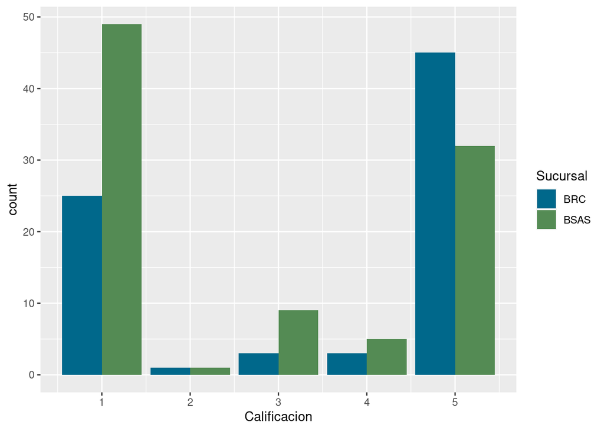

Podemos observar, como se ha expuesto en la introducción, que las sucursales de **Buenos Aires** obtienen mayor cantidad de **calificaciones bajas**, mientras que en **Bariloche** obtienen calificaciones **mayormente altas**.

#### Agregamos al gráfico la variante de **fechas** para evaluar qué sucede en diferentes épocas del año.

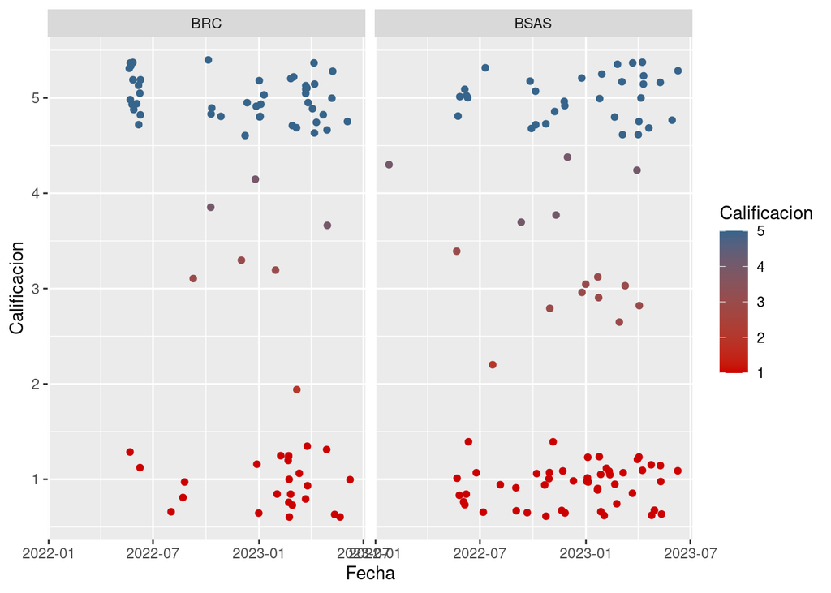

Podemos notar que las **opiniones negativas incrementan** en ambas sucursales a partir de enero, aunque en Bariloche también aumenta la cantidad de **calificaciones altas** y en Buenos Aires se mantiene (aproximadamente) la misma cantidad.

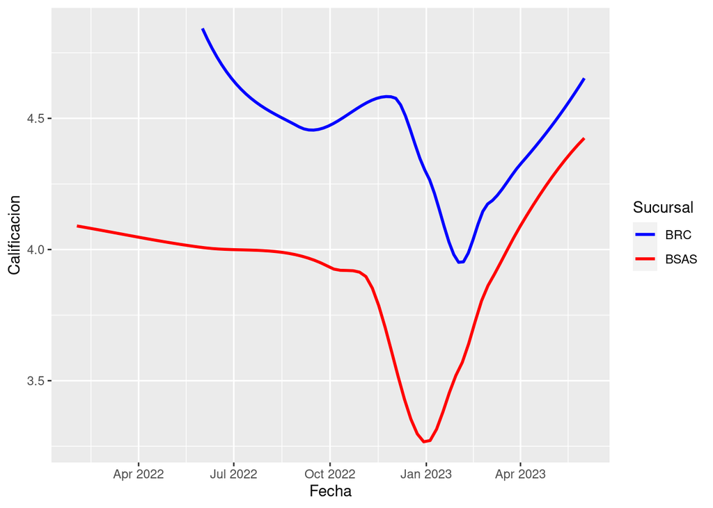

El aumento de opiniones negativas, a pesar de la cantidad de opiniones positivas, genera una **decreción de calificación** en ambas sucursales.

Calculando un promedio de calificaciones, el gráfico que obtenemos es el siguiente:

[figure not shown]

### Filtrando las opiniones

```r
totales_suc<-
  WU_DATA %>%
  group_by(Sucursal) %>%
  count(Sucursal)

names(totales_suc)[2]<-"Total"

mala_atencion<-
  WU_DATA %>%
  group_by(Sucursal) %>%
  filter(B_Atencion=="No")%>%
  count(B_Atencion=="No")%>%
  select(Sucursal,n)
names(mala_atencion)[2]<-"Total_MA"

totales_suc<-
  merge(totales_suc,mala_atencion)


buena_atencion<-
  WU_DATA %>%
  group_by(Sucursal) %>%
  filter(B_Atencion!="No")%>%
  count(B_Atencion!="No")%>%
  select(Sucursal,n)
names(buena_atencion)[2]<-"Total_BA"

totales_suc<-
  merge(totales_suc,buena_atencion)
rm(buena_atencion)
rm(mala_atencion)
```

Como la cantidad de opiniones sobre las sucursales de Buenos Aires es superior a las de Bariloche, calculamos por porcentajes, ya que hacer un gráfico con los datos como están **no mostraría una diferencia real**.

```r
totales_suc$Pje_MA<-
  totales_suc$Total_MA*100 / totales_suc$Total
totales_suc$Pje_BA<-
  totales_suc$Total_BA*100 / totales_suc$Total
```

### Gráfico de porcentajes de mala atención

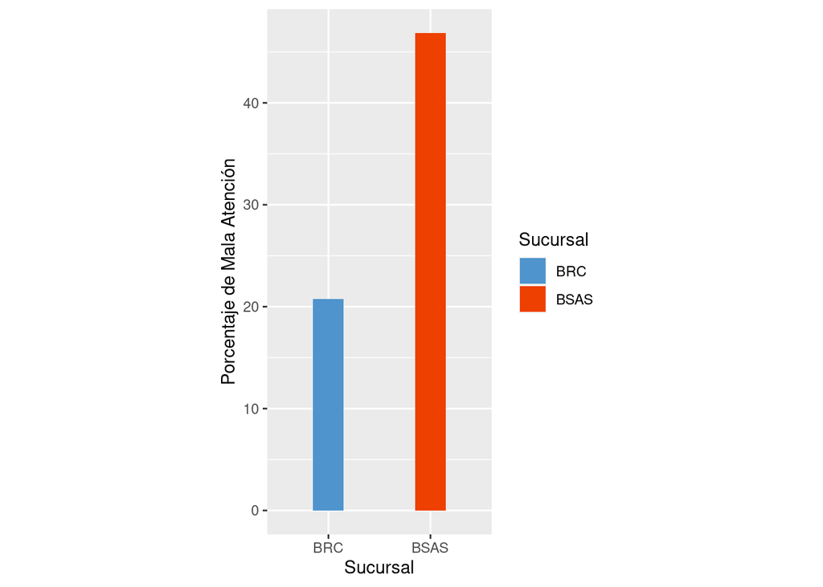

Este último gráfico nos indica que, además de la diferencia de calificaciones, hay una notable diferencia en cuanto a **la atención recibida en cada sucursal**.

### Analizando las principales quejas

```r
quejas_p<-
  WU_DATA %>%
  filter(B_Atencion=="No") %>%
  group_by(Sucursal)%>%
  count(Motivo1)

quejas_p<-
  merge(quejas_p,totales_suc)

names(quejas_p)[2] <- "Motivo_Principal"
names(quejas_p)[3] <- "CQuejas"

quejas_p<-
  quejas_p%>%
  select(Sucursal,Motivo_Principal,CQuejas,Total_MA)


quejas_p$Pje<-
  quejas_p$CQuejas*100 / quejas_p$Total_MA

quejas_s <-
  WU_DATA %>%
  filter(B_Atencion=="No") %>%
  group_by(Sucursal)%>%
  count(Motivo2)

quejas_s <-
  merge(quejas_s,totales_suc)
names(quejas_s)[2] <- "Motivo_Secundario"
names(quejas_s)[3] <- "NQuejas"

quejas_s <-
  quejas_s%>%
  select(Sucursal,Motivo_Secundario,NQuejas,Total_MA)

quejas_s$Pje <-
  quejas_s$NQuejas*100/quejas_s$Total_MA
```

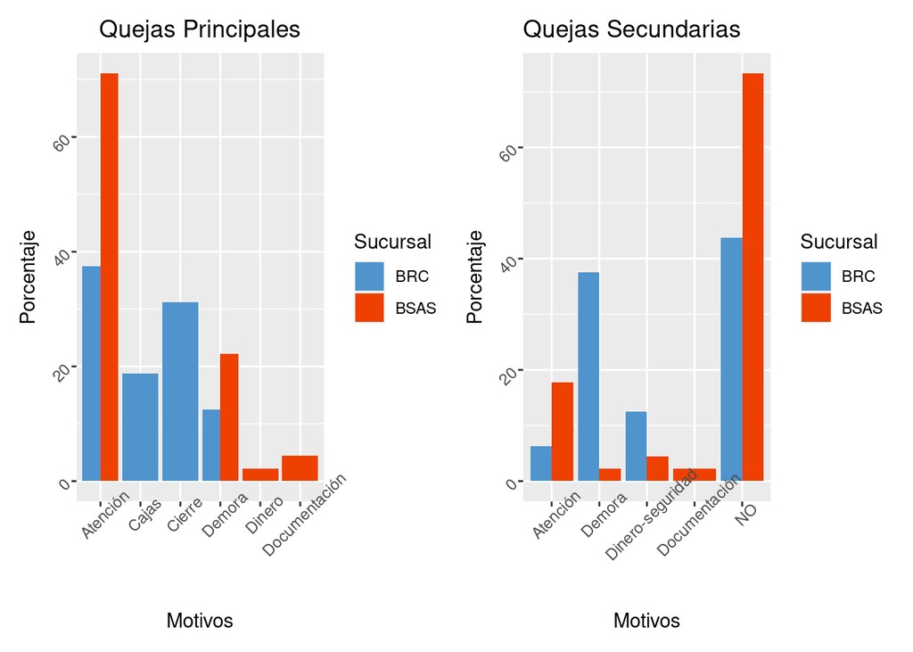

### Analizando los gráficos

Al observar y comparar los gráficos de quejas principales y quejas secundarias, descubrimos que en Buenos Aires la mayoría de las opiniones no poseen un segundo motivo al calificar negativamente, siendo la mala atención el principal y único motivo de queja con un amplio porcentaje; en las opiniones con dos motivos, la mala atención sigue destacando.

Entonces, ¿cuál es el motivo principal en Buenos Aires que tiene como motivo secundario la mala atención?

```
## # A tibble: 8 × 3
##   Sucursal Motivo1 Motivo2
##   <chr>    <chr>   <chr>
## 1 BSAS     Demora  Atención
## 2 BSAS     Demora  Atención
## 3 BSAS     Demora  Atención
## 4 BSAS     Demora  Atención
## 5 BSAS     Dinero  Atención
## 6 BSAS     Demora  Atención
## 7 BSAS     Demora  Atención
## 8 BSAS     Demora  Atención
```

Con estos datos podemos concluir que el problema en Buenos Aires radica **específicamente en la atención recibida y la demora**.

#### ¿Qué sucede en Bariloche?

Volviendo a los gráficos,

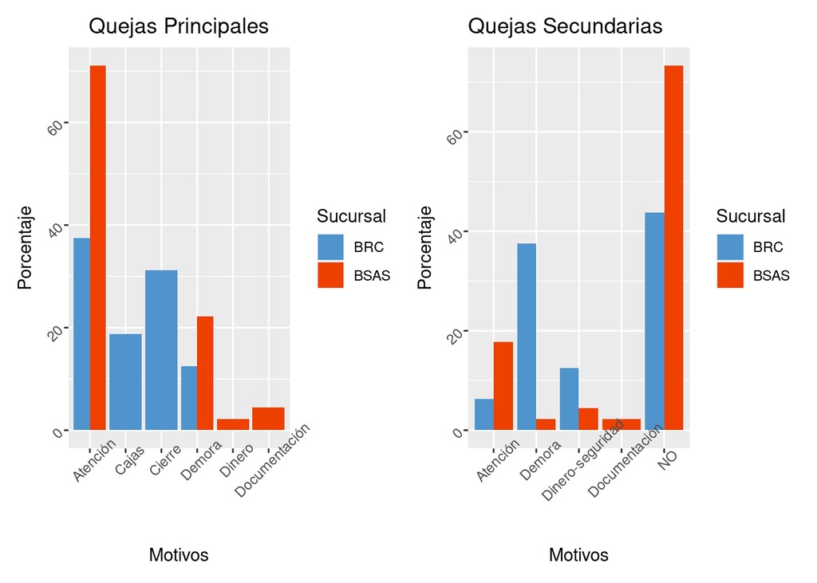

podemos ver que entre los motivos principales no hay una diferencia tan marcada, siendo la atención, el cierre y la cantidad de cajas los motivos principales; pero al agregar los motivos secundarios sí se observa una diferencia marcada, destacando la demora como el principal motivo secundario.

### ¿Existe relación entre la demora y la falta de cajas?

Para el siguiente gráfico se analizaron todos los comentarios, independientemente de la atención recibida, referidos a la lentitud de la atención, discriminando los motivos de queja que agregaron.

Para tener datos más precisos, se descartaron aquellos comentarios que no indicaban otro motivo que no fuese la demora.

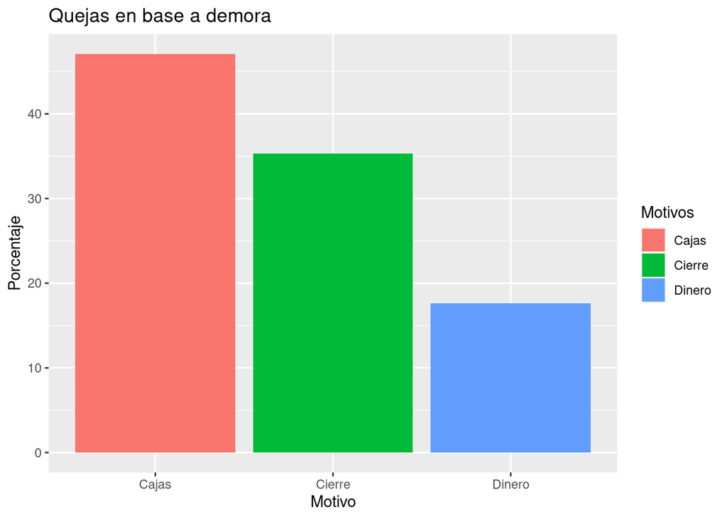

Queda claro, observando el gráfico, que la falta de cajas es el motivo principal que aqueja a los clientes que se refieren a la poca rapidez del servicio.

## Conclusión

En base a lo observado y expuesto, respecto a las sucursales de Buenos Aires, es primordial **enfocarse en la atención** de los empleados hacia los clientes.

En cuanto a Bariloche, **la falta de cajas** es la principal problemática a solucionar para mejorar el servicio. Por otro lado, podemos ver que **el horario de cierre** es otro punto a tener en cuenta de **manera urgente**, dado que, no sólo es el segundo motivo de quejas en base a las demoras, sino que obtiene un porcentaje notable.

Como soluciones optativas para las problemáticas, se sugiere realizar cursos de capacitación de atención al personal e inspecciones no programadas, la contratación de más cajeros y establecer un horario para el cierre de la puerta del local anterior al horario de finalización de atención.